# Visualizing Data with R: From Basics to Publication-Ready Graphics–Part 2

$~$

We can also use predefined color palettes:

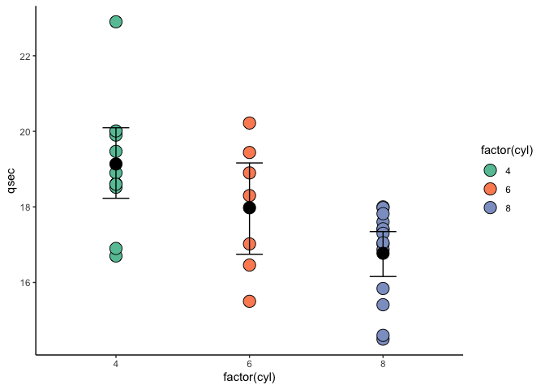

```r
ggplot(data = mtcars, aes(x = factor(cyl), y = qsec)) +
  geom_point(size = 5, pch = 21, color = "black", aes(fill = factor(cyl))) +
  stat_summary(fun.data = mean_cl_boot, geom = "errorbar",
        color = "black", width = 0.2) +
  stat_summary(fun = mean, geom = "point",
    size = 5, color = "black") +
  scale_fill_brewer(palette = "Set2")
```

You can view the color options like this:

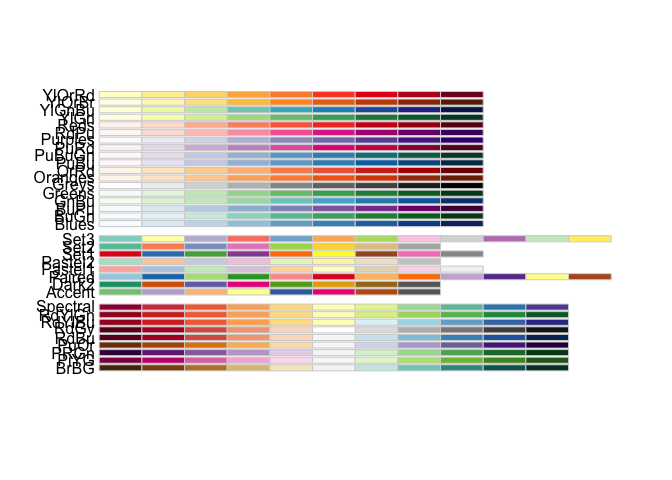

```r
RColorBrewer::display.brewer.all()
```

$~$

We can also use a [color pallet generator](https://coolors.co/) for custom color pallets. This site generates random color pallets or allows you to create your own. Additionally, if you have a picture that represents your research you can upload it to generate a specialized color pallet. Let’s look at a randomly generated color pallet:

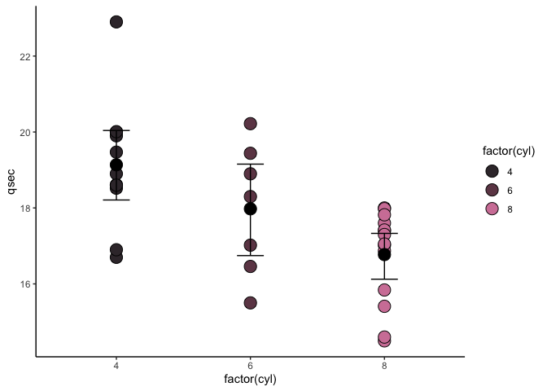

```r
ggplot(data = mtcars, aes(x = factor(cyl), y = qsec)) +
  geom_point(size = 5, pch = 21, color = "black", aes(fill = factor(cyl))) +
  stat_summary(fun.data = mean_cl_boot, geom = "errorbar",
        color = "black", width = 0.2) +
  stat_summary(fun = mean, geom = "point",
    size = 5, color = "black") +
  scale_fill_manual(values = c("#3A3238", "#6E4555", "#D282A6"))
```

$~$

Suppose we want to highlight 8-cylinder vehicles relative to those with 4 or 6 cylinders. We’ll use electric blue for the 8-cylinder vehicles to make them stand out, and a grey scale for the others. To enhance visibility and prevent overlapping, we’ll apply `position_jitter` to the points, slightly offsetting them within their categories.

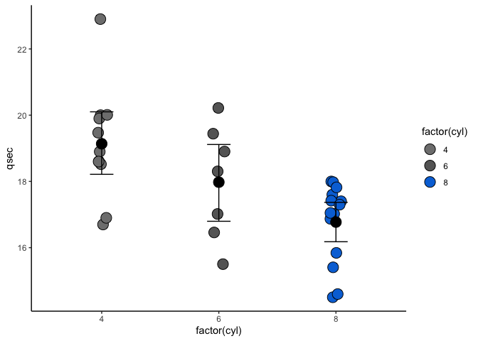

```r
ggplot(data = mtcars, aes(x = factor(cyl), y = qsec)) +
  geom_point(position = position_jitter(width = 0.05),   # Slightly offset points
             size = 5, pch = 21, color = "black",
             aes(fill = factor(cyl))) +
  stat_summary(fun.data = mean_cl_boot, geom = "errorbar",
        color = "black", width = 0.2) +
  stat_summary(fun = mean, geom = "point",
    size = 5, color = "black") +
  scale_fill_manual(values = c("grey50", "grey40", "#0074D9"))
```

$~$

### 4.3 Labels and Axes

Labels and axes are essential components of any plot, as they provide context and help the viewer interpret the data. In ggplot2, you can customize these elements using functions like `labs()` and `scale_x_continuous()` or `scale_y_continuous()`. Let’s start by changing the names of our categories.

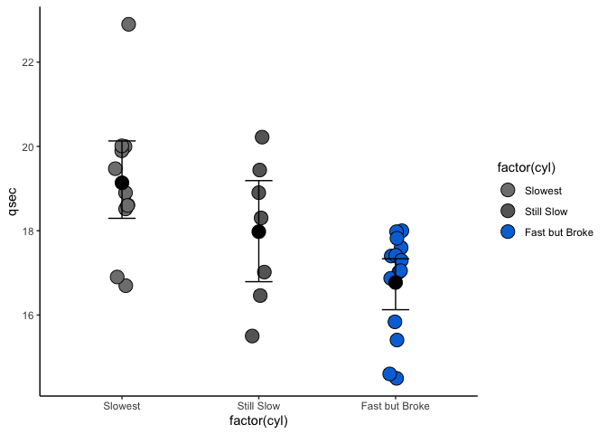

```r
ggplot(data = mtcars, aes(x = factor(cyl), y = qsec)) +
  geom_point(position = position_jitter(width = 0.05), size = 5, pch = 21, color = "black", aes(fill = factor(cyl))) +
  stat_summary(fun.data = mean_cl_boot, geom = "errorbar",
        color = "black", width = 0.2) +
  stat_summary(fun = mean, geom = "point",
    size = 5, color = "black") +
  scale_fill_manual(
    values = c("grey50", "grey40", "#0074D9"),
    labels = c("4" = "Slowest",
               "6" = "Still Slow",
               "8" = "Fast but Broke")) +        # Custom legend labels
  scale_x_discrete(labels = c("4" = "Slowest",
                              "6" = "Still Slow",
                              "8" = "Fast but Broke"))     # Custom x axis labels
```

$~$

Let’s change more labels.

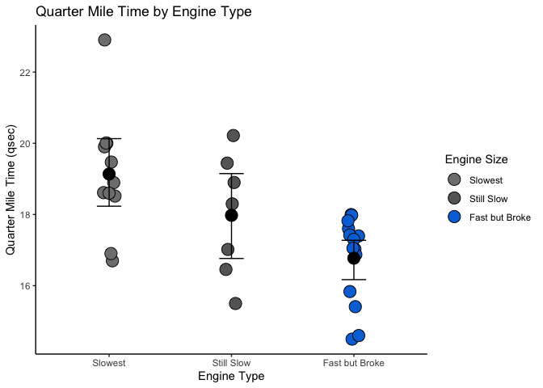

```r
ggplot(data = mtcars, aes(x = factor(cyl), y = qsec)) +
  geom_point(position = position_jitter(width = 0.05), size = 5, pch = 21, color = "black", aes(fill = factor(cyl))) +
  stat_summary(fun.data = mean_cl_boot, geom = "errorbar",
        color = "black", width = 0.2) +
  stat_summary(fun = mean, geom = "point",
    size = 5, color = "black") +
  scale_fill_manual(
    values = c("grey50", "grey40", "#0074D9"),
    labels = c("4" = "Slowest",
               "6" = "Still Slow",
               "8" = "Fast but Broke")) +        # Custom legend labels
  scale_x_discrete(labels = c("4" = "Slowest",
                              "6" = "Still Slow",
                              "8" = "Fast but Broke")) +    # Custom x axis labels
  labs(
    x = "Engine Type",  # X-axis label
    y = "Quarter Mile Time (qsec)",  # Y-axis label
    fill = "Engine Size",  # Legend title
    title = "Quarter Mile Time by Engine Type")  # Plot title
```

$~$

We can also adjust the y-axis:

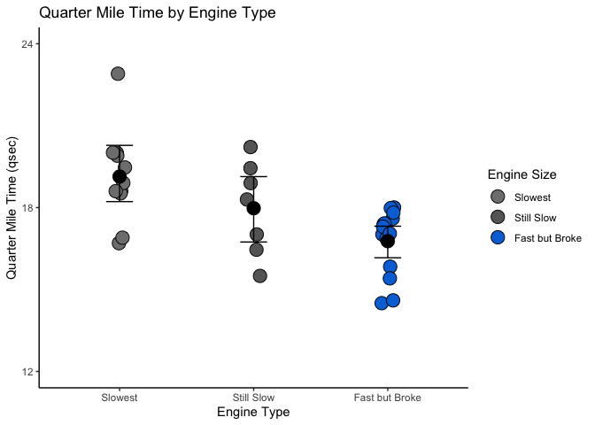

```r
ggplot(data = mtcars, aes(x = factor(cyl), y = qsec)) +
  geom_point(position = position_jitter(width = 0.05), size = 5, pch = 21, color = "black", aes(fill = factor(cyl))) +
  stat_summary(fun.data = mean_cl_boot, geom = "errorbar",
        color = "black", width = 0.2) +
  stat_summary(fun = mean, geom = "point",
    size = 5, color = "black") +
  scale_fill_manual(
    values = c("grey50", "grey40", "#0074D9"),
    labels = c("4" = "Slowest",
               "6" = "Still Slow",
               "8" = "Fast but Broke")) +        # Custom legend labels
  scale_x_discrete(labels = c("4" = "Slowest",
                              "6" = "Still Slow",
                              "8" = "Fast but Broke")) +    # Custom x axis labels
  scale_y_continuous(breaks=c(12, 18, 24), limits=c(12,24))+ # Set axis limits and numbers
  labs(
    x = "Engine Type",  # X-axis label
    y = "Quarter Mile Time (qsec)",  # Y-axis label
    fill = "Engine Size",  # Legend title
    title = "Quarter Mile Time by Engine Type")  # Plot title
```

**Tip:** This is great for standardizing multiple plots. You can also use `scale_x_continuous()` in the same way.

$~$

We can also edit the sizes and fonts of the axis:

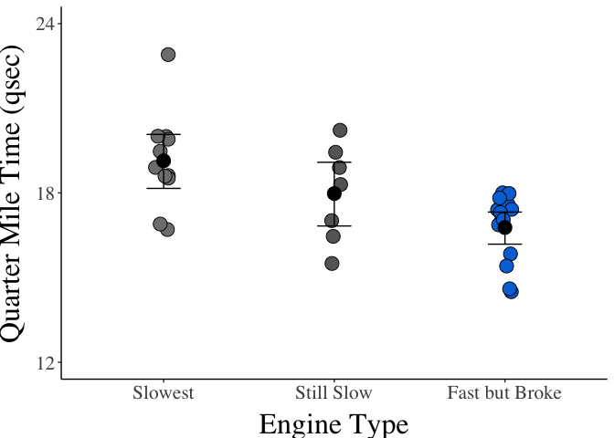

```r
ggplot(data = mtcars, aes(x = factor(cyl), y = qsec)) +
  geom_point(position = position_jitter(width = 0.05), size = 5, pch = 21, color = "black", aes(fill = factor(cyl))) +
  stat_summary(fun.data = mean_cl_boot, geom = "errorbar",
        color = "black", width = 0.2) +
  stat_summary(fun = mean, geom = "point",
    size = 5, color = "black") +
  scale_fill_manual(
    values = c("grey50", "grey40", "#0074D9"),
    labels = c("4" = "Slowest",
               "6" = "Still Slow",
               "8" = "Fast but Broke")) +        # Custom legend labels
  scale_x_discrete(labels = c("4" = "Slowest",
                              "6" = "Still Slow",
                              "8" = "Fast but Broke")) +    # Custom x axis labels
  scale_y_continuous(breaks=c(12, 18, 24), limits=c(12,24))+ # Set axis limits and numbers
  labs(
    x = "Engine Type",  # X-axis label
    y = "Quarter Mile Time (qsec)",  # Y-axis label
    fill = "Engine Size") + # Legend title
  theme(
    axis.title.x = element_text( size=24, family= "Times", vjust=-0.2),
    axis.text.x  = element_text( size=16, family= "Times"),
    axis.title.y = element_text( size=24, family= "Times", vjust=2), # vjust is the distance from the text
    axis.text.y  = element_text( size=16, family= "Times"),
    legend.position = "none")
```

#### Try it for yourself:

Edit the plot yourself: chose different colors, shapes, titles, and adjustments:

```r
ggplot(data = mtcars, aes(x = factor(cyl), y = qsec)) +
  geom_point(position = position_jitter(width = 0.05), size = 5, pch = 21, color = "black", aes(fill = factor(cyl))) +
  stat_summary(fun.data = mean_cl_boot, geom = "errorbar",
        color = "black", width = 0.2) +
  stat_summary(fun = mean, geom = "point",
    size = 5, color = "black") +
  scale_fill_manual(
    values = c("grey50", "grey40", "#0074D9"),
    labels = c("4" = "Slowest",
               "6" = "Still Slow",
               "8" = "Fast but Broke")) +        # Custom legend labels
  scale_x_discrete(labels = c("4" = "Slowest",
                              "6" = "Still Slow",
                              "8" = "Fast but Broke")) +    # Custom x axis labels
  scale_y_continuous(breaks=c(12, 18, 24), limits=c(12,24))+ # Set axis limits and numbers
  labs(
    x = "Engine Type",  # X-axis label
    y = "Quarter Mile Time (qsec)",  # Y-axis label
    fill = "Engine Size") + # Legend title
  theme(
    axis.title.x = element_text( size=20, family= "Times", vjust=-0.2),
    axis.text.x  = element_text( size=16, family= "Times", angle = 45, hjust=1, margin=margin(t=-1, b=10)),
    axis.title.y = element_text( size=20, family= "Times", vjust=2), # vjust is the distance from the text
    axis.text.y  = element_text( size=16, family= "Times"),
    axis.line.x = element_line( linewidth =3),
    legend.position = "none")
```

## 5. Example–Bubble Plot

Let’s walk through an example of how to create a figure. Let’s explore the life expectancy by Gross Domestic Product (GDP, a measure of a country’s economic activity) per capita for each country in the year 2007 while taking into account population size.

We’ll use a new dataset, provided in the `gapminder` package, and use some additional packages for color pallets and annotations. First, we need to download our data:

```r
if (!requireNamespace("gapminder", quietly = TRUE)) {
  install.packages("gapminder")
}

library(gapminder)
data("gapminder")
```

```r
# Filter out 2007 data
data <- gapminder %>%
  filter(year=="2007") %>%
  dplyr::select(-year)
# Changing values, sorting, and setting factor levels for plotting
data %>%
mutate(pop=pop/1000000) %>%
arrange(desc(pop)) %>%
mutate(country = factor(country))
```

```
## # A tibble: 142 × 5
##    country       continent lifeExp   pop gdpPercap
##    <fct>         <fct>       <dbl> <dbl>     <dbl>
##  1 China         Asia         73.0 1319.     4959.
##  2 India         Asia         64.7 1110.     2452.
##  3 United States Americas     78.2  301.    42952.
##  4 Indonesia     Asia         70.6  224.     3541.
##  5 Brazil        Americas     72.4  190.     9066.
##  6 Pakistan      Asia         65.5  169.     2606.
##  7 Bangladesh    Asia         64.1  150.     1391.
##  8 Nigeria       Africa       46.9  135.     2014.
##  9 Japan         Asia         82.6  127.    31656.
## 10 Mexico        Americas     76.2  109.    11978.
## # ℹ 132 more rows
```

Now let’s plot the GDP per capita by life expectancy in the year 2007, while displaying population size and coloring by continent. Let’s also use the package `viridis` for our color pallet.

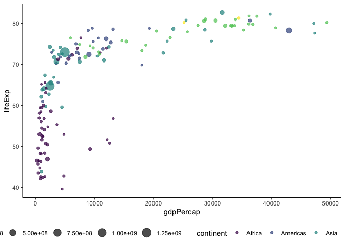

```r
# Let's install a new package for a better color pallet

if (!requireNamespace("viridis", quietly = TRUE)) {
  install.packages("viridis")
}

library(viridis)                                   # color scales


# Plot
ggplot(data, aes(x=gdpPercap, y=lifeExp, size = pop, color = continent)) +
  geom_point(alpha=0.7) +
  scale_color_viridis(discrete=TRUE) +
  theme(legend.position="bottom")
```

The size here is not ideal and the legend is unappealing. Let’s use a new scale function to address this:

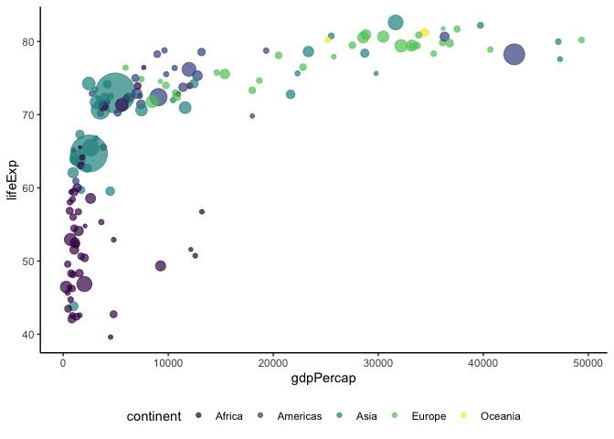

```r
# Plot
ggplot(data, aes(x=gdpPercap, y=lifeExp, size = pop, color = continent)) +
  geom_point(alpha=0.7) +
  scale_size(range = c(1, 15), guide = "none") + # set population sizes and remove legend
  scale_color_viridis(discrete=TRUE) +
  theme(legend.position="bottom")
```

Although this plot shows lots of information we may also want to point out instances that meet specific requirements we are interested in. Let’s annotate countries that:

1. GDP per capita is greater than 5,000 and life expectancy is below 60 years.
2. GDP per capita is greater than 40,000.

ggplot is widely used and there are lots of packages that add additional features you may want to use. For these annotations we will be using `ggrepel`, you can read more about it [here](https://cran.r-project.org/web/packages/ggrepel/readme/README.html).

We will first add a column to our dataset specifying if the country will be annotated.

```r
# Packge for annotations with "geom_text_repel"
if (!requireNamespace("ggrepel", quietly = TRUE)) {
  install.packages("ggrepel")
}


library(ggrepel)                                   # extra geoms for ggplot2


# Prepare data
tmp <- data %>%
mutate(annotation = case_when(
  gdpPercap > 5000 & lifeExp < 60 ~ "yes",
  gdpPercap > 40000 ~ "yes"))
```

Next, we will create our plot and annotate it with `geom_text_repel`. We can look more into this function and how to use it by using:

```r
?geom_text_repel
```

Now let’s create our plot:

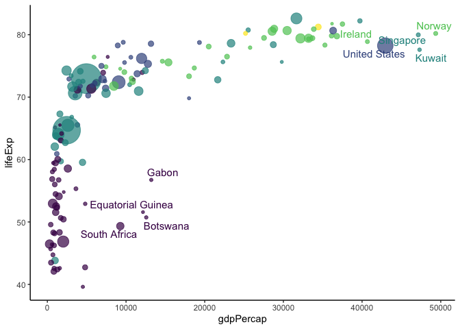

```r
# Plot
ggplot(tmp, aes(x=gdpPercap, y=lifeExp, size = pop, color = continent)) +
  geom_point(alpha=0.7) +
  scale_size(range = c(1, 15), guide = "none") +
  scale_color_viridis(discrete=TRUE) +
  theme(legend.position="none") + # Remove both legends for aestetics
  geom_text_repel(data=tmp %>% filter(annotation=="yes"), aes(label=country), size=4 )
```

Let’s use our customization skills.

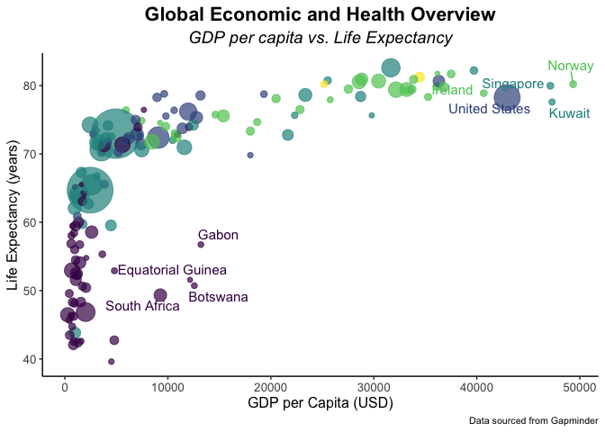

```r
ggplot(tmp, aes(x = gdpPercap, y = lifeExp, size = pop, color = continent)) +
  geom_point(alpha = 0.7) +
  scale_size(range = c(1.4, 19), name = "Population (Millions)") +
  scale_color_viridis(discrete = TRUE) +
  labs(
    title = "Global Economic and Health Overview",
    subtitle = "GDP per capita vs. Life Expectancy",
    x = "GDP per Capita (USD)",
    y = "Life Expectancy (years)",
    caption = "Data sourced from Gapminder"
  ) +
  theme(
    legend.position = "none",
    plot.title = element_text(size = 16, face = "bold", hjust = 0.5),
    plot.subtitle = element_text(size = 14, face = "italic", hjust = 0.5),
    plot.caption = element_text(size = 8),
    axis.title.x = element_text(size = 12),
    axis.title.y = element_text(size = 12),
    axis.text.x = element_text(size = 10),
    axis.text.y = element_text(size = 10)
  ) +
  geom_text_repel(
    data = tmp %>% filter(annotation == "yes"),
    aes(label = country),
    size = 4
  )
```

## 6. Exercises

$~$

Create this image:

$~$

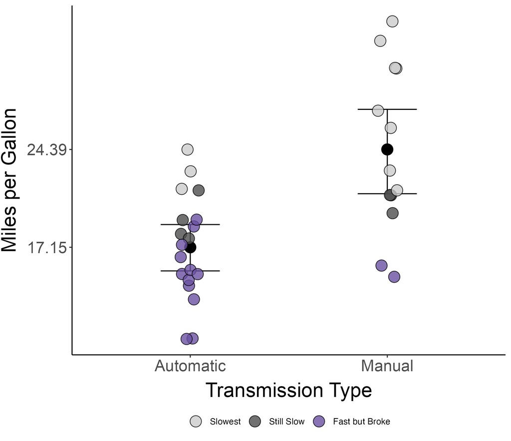

$~$

```r
# Here is some helpful code
am0 <-subset(mtcars, am == 0)
am1 <-subset(mtcars, am == 1)
mn0 <- round(mean(am0$mpg), 2)
mn1 <- round(mean(am1$mpg), 2)


# Create plot here
```

$~$

Create this image:

$~$

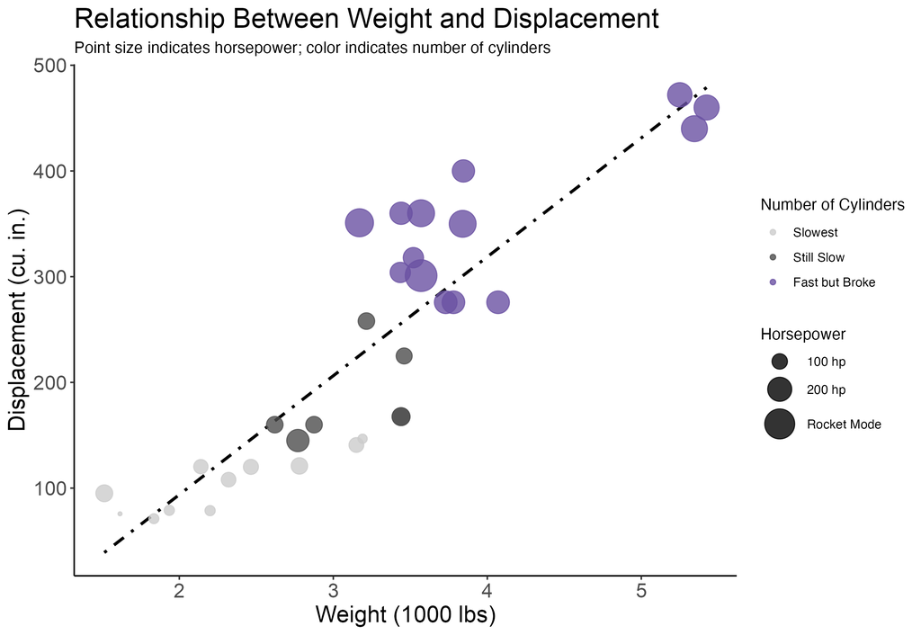

$~$

## 7. Summary

In this module, we explored various aspects of data visualization using `ggplot2` in R. We began by summarizing data using the `dplyr` package, which allowed us to compute descriptive statistics like means and standard deviations, which we visualized using bar graphs and error bars.

We then discussed the importance of displaying raw data to provide a complete picture of the dataset, beyond just summary statistics. We used boxplots, violin plots, and points to show raw data distributions and variability among groups, emphasizing how these visualizations can reveal data points and trends that summary statistics alone might obscure.

We learned to customize plots to enhance readability and aesthetic appeal. We covered:

- **Themes:** How changing the theme can dramatically alter the visual presentation of data. We focused on `theme_classic()` for its clean and professional appearance.
- **Shapes and Colors:** The use of `pch` options and color to differentiate data points visually on the plot. We discussed the difference between `color` and `fill` and how to appropriately use them.
- **Labels and Axes:** Customizing plot labels and axes to improve plot clarity and convey precise information about the data visualized. This includes modifying text and axis sizes, styles, and positions.

Remember, effective data visualization is not just about displaying data but about telling a story that is clear and engaging.